# TP2-MPA

Imad EZ-ZEJJARI

## Question 1

Cas $c=1$ avec la fréquence $\theta_2$:

$p(y|c=1,\theta_1,\theta_2)$

$=p(y|\theta_2)$

$=p(y_1...y_n|\theta_2)$

$=\prod_{i=1}^{n} p(y_i|\theta_2)$ , ($y_1...y_n$ indépendantes)

or

$$p(y_i|\theta_2) = \left\{
\begin{array}{ll}
\theta_2 & \mbox{si } y_i=1 \\
1-\theta_2 & \mbox{si } y_i=0
\end{array}
\right.$$

donc $p(y_i|\theta_2)=\theta_2^{y_i}(1-\theta_2)^{1-y_i}$

et $p(y|c=1,\theta_1,\theta_2)=\prod_{i=1}^{n}\theta_2^{y_i}(1-\theta_2)^{1-y_i}$

## Question 2

Cas $c>2$:

$p(y|c>1,\theta_1,\theta_2)$

$=p(y_1...y_n|c>1,\theta_1,\theta_2)$

$=p(y_1...y_{c-1}|c>1,\theta_1,\theta_2)p(y_c...y_n|c>1,\theta_1,\theta_2)$

$=\prod_{i=1}^{c-1}p(y_i|c>1,\theta_1,\theta_2)\prod_{i=c}^{n}p(yi|c>1,\theta_1,\theta_2)$

$=\prod_{i=1}^{c-1}\theta_1^{y_i}(1-\theta_1)^{1-y_i}\prod_{i=c}^{n}\theta_2^{y_i}(1-\theta_2)^{1-y_i}$

## Question 3

Soit $c\in[2,n]$

$\frac{p(c|y)}{p(c=1|y)}=\frac{\frac{p(y|c)^(c)}{p(y)}}{\frac{p(y|c=1)p(c=1)}{p(y)}}$

or $p(\theta)=p(c)p(\theta_1)p(\theta_2)$ pour $c\geq2$

et pour $c=1$, on a aussi $p(\theta)=p(c=1)p(\theta_1)p(\theta_2)$

Donc $p(c)=p(c=1)$

alors $\frac{p(c|y)}{p(c=1|y)}$

$=\frac{p(y|c)}{p(y|c=1)}$

$=\frac{\prod_{i=1}^{c-1}\theta_1^{y_i}(1-\theta_1)^{1-y_i}\prod_{i=c}^{n}\theta_2^{y_i}(1-\theta_2)^{1-y_i}}{\prod_{i=1}^{c-1}\theta_2^{y_i}(1-\theta_2)^{1-y_i}\prod_{i=c}^{n}\theta_2^{y_i}(1-\theta_2)^{1-y_i}}$

$=\prod_{i=1}^{c-1}\frac{\theta_1^{y_i}(1-\theta_1)^{1-y_i}}{\theta_2^{y_i}(1-\theta_2)^{1-y_i}}$

$=\prod_{i=1}^{c-1}(\frac{\theta1}{\theta2})^{y_i}(\frac{1-\theta1}{1-\theta2})^{1-y_i}$

On calcule d’abord les ratios $\frac{\theta1}{\theta2}=c_1$ et $\frac{1-\theta1}{1-\theta2}=c_2$ dont le coût est de 2 multiplications.

On effectue ensuite un algorithme (de l’étape 1 à c-1) qui fait à chaque étape i : $résulat=résultat\times ratios$

où

$$ratios = \left\{
\begin{array}{ll}
c1 & \mbox{si } y_i=1, (+1 multiplication)\\
c2 & \mbox{si } y_i=0, (+1 multiplication)
\end{array}
\right.$$
Et comme il y a c-1 multiplications:

$\underbrace{c_1\times c_2\times ...\times c_{c-1}}_{(c-1) multiplications}$ car si on considére qu’on a g $y_i = 1$ et h $y_i = 0$ or le nombre de multiplication est $g-1+1=g$ avec 1 pour le calcul de $=\frac{\theta_1}{\theta_2}$ et g-1 par ce qu’on g-1 multiplication avec $y_i=1$ et la même chose pour h Donc le nombre de multiplication est $h+g=c-1$ Donc $\sum_{i=2}^{n}(c-1)$

$u=c-1$

$=\sum_{u=1}^{n-1}u$

$=\frac{n(n-1)}{2}$

C’est donc de l’ordre de $\frac{n(n-1)}{2}$

## Question 4

```r
calcul_ratio_q3 <- function(y, c, theta1, theta2){
  produit = 1
  val = c-1
  for (i in 1:val){
    if (y[i] == 1){
      coef = theta1/theta2
    }else if (y[i] == 0){
      coef = (1-theta1)/(1-theta2)
    }
    produit = produit*coef
  }
  return(produit)
}
calcul_proba_c_egale_1 <- function(y, theta1, theta2){
  somme = 0
  for (c in 2:length(y)){
    somme = somme+calcul_ratio_q3(y, c, theta1, theta2)
  }
  resultat = 1/(1+somme)
  return (resultat)
}
calculer_c_sachant_y <- function(y, theta1, theta2){
  resulat_c1= calcul_proba_c_egale_1(y,theta1,theta2)
  c = c(resulat_c1)
  for (i in 2:length(y)){
    c= append(c, calcul_ratio_q3(y, i, theta1, theta2)*resulat_c1)
  }
  return(c)
}
vecteur<-scan("TP2_sequence_1_2020.txt")
#c= calculer_c_sachant_y(vecteur, 0.6,0.5)
```

## Question 5

On donne pour commencer des valeurs aléatoires pour $\theta_1$ et $\theta_2$

```r
algo_echantillonage_gibs <- function(y, theta1initiale, theta2initiale){
  compteur = 0
  theta1calcule = theta1initiale
  theta2calcule = theta2initiale
  #print(theta1calcule)
  #print(theta2calcule)
  vecteurc = c()
  debut = 1
  n = length(y)
  while (compteur<100){
    c= calculer_c_sachant_y(y, theta1calcule,theta2calcule)
    c_estime = which.max(c)

    nombre1 = 0
    nombre2 = 0
    val = c_estime-1
    for (j in 1:val){
      if (y[j+1] == 1){
        nombre1 = nombre1+1
      }
    }
    if (c_estime == 1){
      theta1calcule = 0
    }else{
      theta1calcule = nombre1/(c_estime-1)
    }
    for (j in c_estime:n){
      if (y[j] == 1){
        nombre2 = nombre2+1
      }
    }
    theta2calcule = nombre2/(n-c_estime+1)
    #print(theta1calcule)
    #print(theta2calcule, theta1calcule)
    vecteurc = c(vecteurc, c_estime)
    compteur = compteur+1
    #if (compteur == 1000){
    #  #print(vecteurc)
    #  print(0)
    #  return()
    #}
  }
  #print(vecteurc)
  resultat = c(vecteurc[length(vecteurc)], theta1calcule, theta2calcule)
  return(resultat)
}
```

```r
theta1=runif(1,0,1)
theta2=runif(1,0,1)
vecteur2 = rbinom(50,size=1, theta1)
vecteur2 = c(vecteur2, rbinom(100,size=1, theta2))
algo_echantillonage_gibs(vecteur2, theta1, theta2)
```

```
## [1] 47.0000000  0.5434783  0.4519231
```

## Question 6

Notre algorithme prend en entrée un y, et puisque on veut savoir la sensibilité aux valeurs conditions intiales, on va varier les deux mais et on va propose soit de superposer le graphe de résultat en fonction de theta1 avec celui de theta2 ou de les tracer séparément

```r
algo_teste_la_convergence <- function(y){
  #prend en entrée un indice pour indiquer la quelle elle va varier et thetainitiale pour indiquer la       valeur de thetafixe
  vecteur_theta1 = c()
  vecteur_theta2 = c()
  resultat = c()
  for (i in 1:100){
    theta1 = runif(1,0,1)
    theta2 = runif(1,0,1)
    vecteur_theta1 = c(vecteur_theta1, theta1)
    vecteur_theta2 = c(vecteur_theta2, theta2)
    valeur = algo_echantillonage_gibs(y, theta1, theta2)
    resultat = c(resultat, valeur[1])
  }

  hist(resultat)
  print(density(resultat))
  plot(density(resultat))
  par(mfcol=c(1,1))
  # représentation du graphe de c en fonction de theta(1 ou 2)
  plot(vecteur_theta1, resultat, col="red", ylab="c_estime(sachant y)", xlab="theta")
  title(main="graphe de p(c/y) en fonction de theta1")
  plot(vecteur_theta2, resultat, col="green", ylab="c_estime(sachant y)", xlab="theta")
   title(main="graphe de p(c/y) en fonction de theta2")

  #points(vecteur_theta_initiale,resultat, col="green")
  #legend(x="bottomright", legend=c("tirages","espérance"), col=c("grey","blue"), pch=c(1, 1))
  print(valeur[2])
  print(valeur[3])
}
```

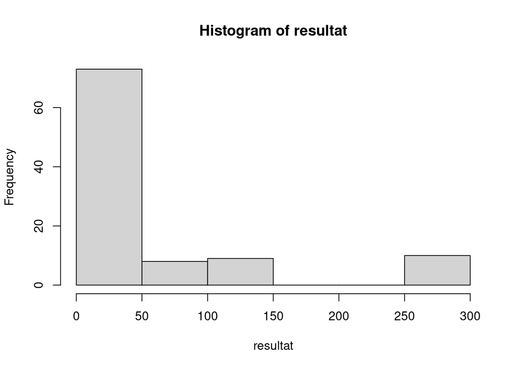

```
##
## Call:
##  density.default(x = resultat)
##
## Data: resultat (100 obs.);   Bandwidth 'bw' = 24.87
##
##        x               y
##  Min.   :-73.6   Min.   :5.610e-06
##  1st Qu.: 36.2   1st Qu.:2.332e-04
##  Median :146.0   Median :1.289e-03
##  Mean   :146.0   Mean   :2.272e-03
##  3rd Qu.:255.8   3rd Qu.:2.367e-03
##  Max.   :365.6   Max.   :1.171e-02
```

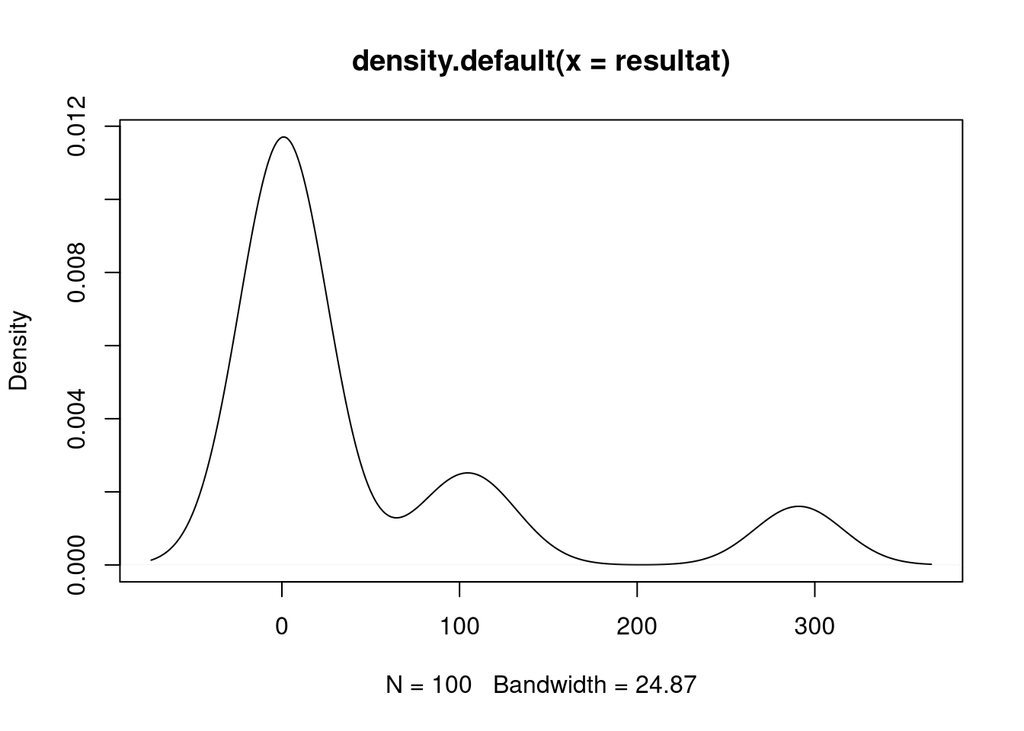

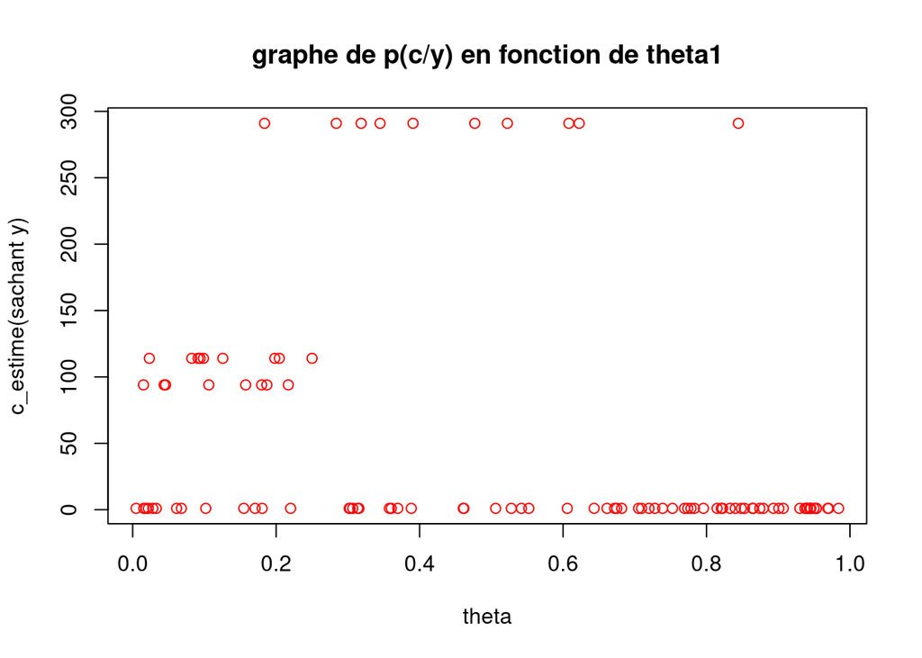

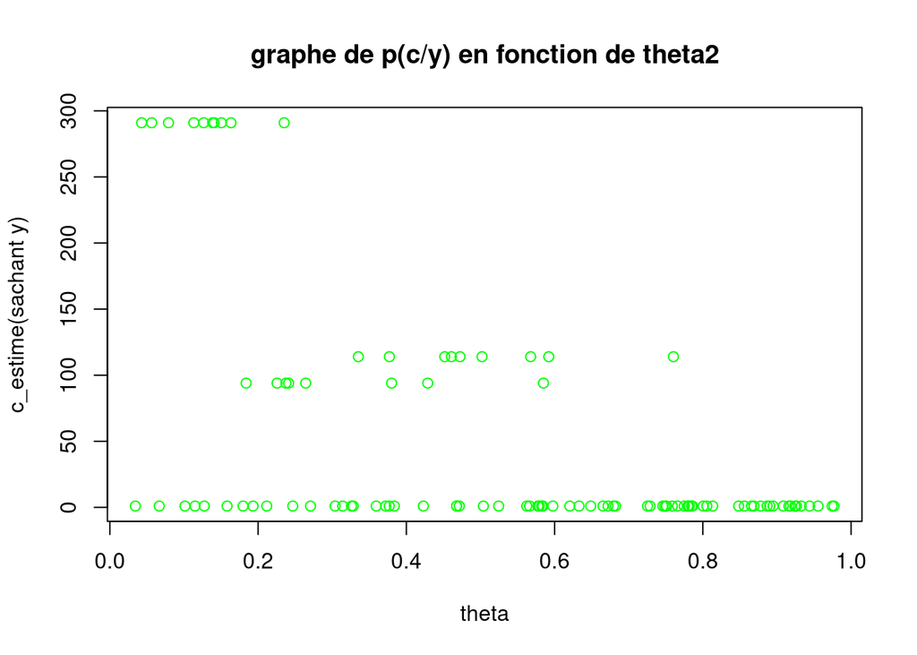

```
## [1] 0
## [1] 0.3056872
```

```r
vecteur<-scan("TP2_sequence_2_2020.txt")
algo_teste_la_convergence(vecteur)
```

On va répéter le même pour l’indice 2:

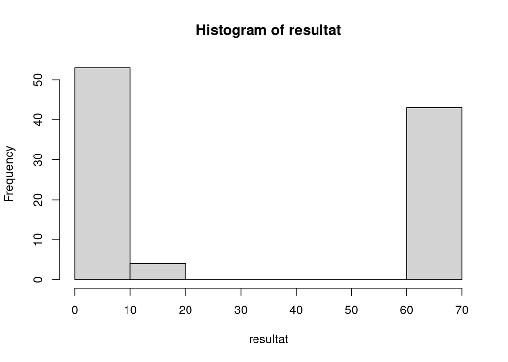

```
##
## Call:
##  density.default(x = resultat)
##
## Data: resultat (100 obs.);   Bandwidth 'bw' = 11.86
##
##        x                  y
##  Min.   :-34.5912   Min.   :0.0001457
##  1st Qu.:  0.2044   1st Qu.:0.0016980
##  Median : 35.0000   Median :0.0057848
##  Mean   : 35.0000   Mean   :0.0071692
##  3rd Qu.: 69.7956   3rd Qu.:0.0123661
##  Max.   :104.5912   Max.   :0.0184398
```

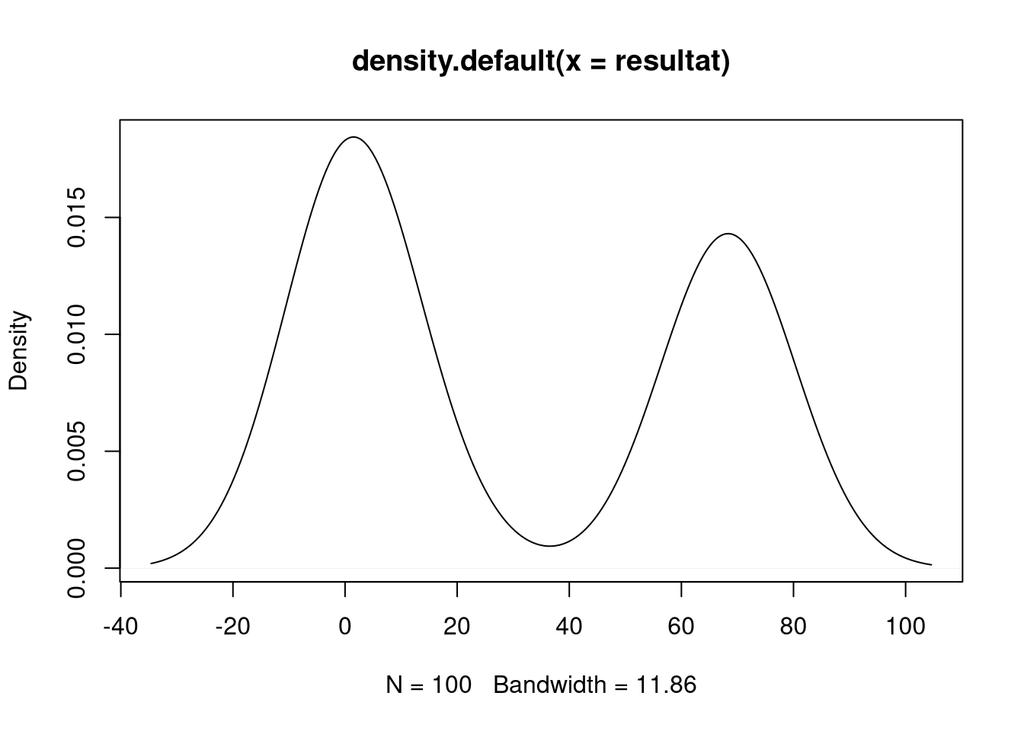

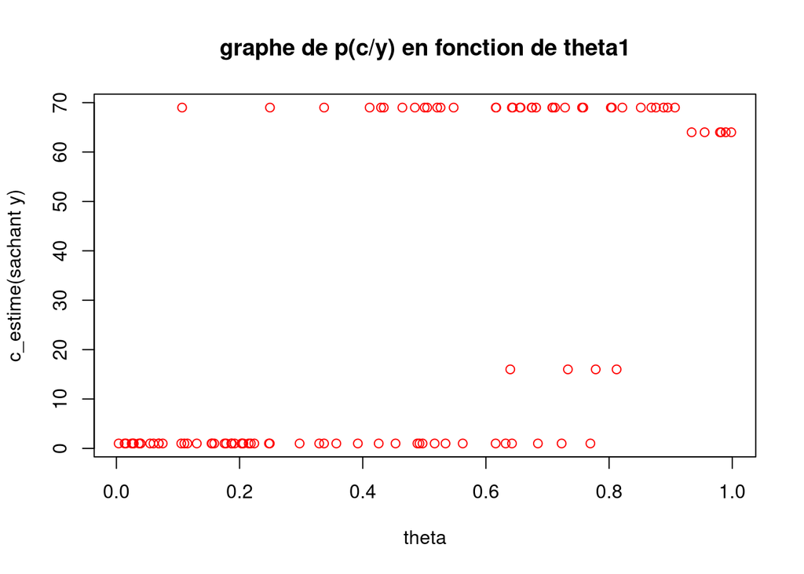

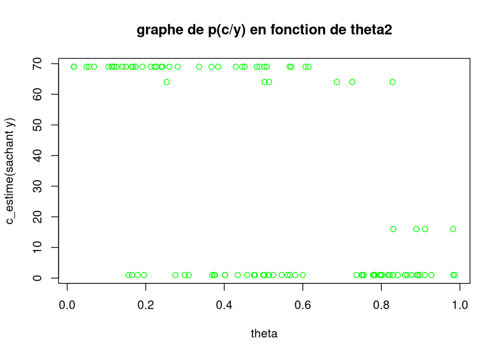

```
## [1] 0.9117647
## [1] 0.5
```

```r
theta1 = runif(1,0,1)
theta2 = runif(1,0,1)
vecteur2 = rbinom(50,size=1, theta1)
vecteur2 = c(vecteur2, rbinom(20,size=1, theta2))
algo_teste_la_convergence(vecteur2)
```

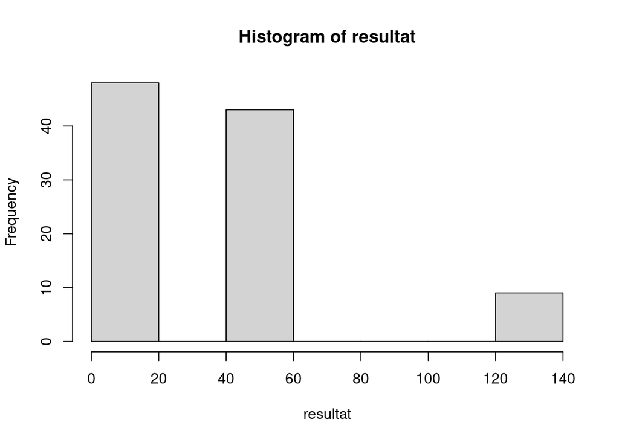

```
##
## Call:
##  density.default(x = resultat)
##
## Data: resultat (100 obs.);   Bandwidth 'bw' = 13.04
##
##        x                y
##  Min.   :-34.13   Min.   :3.094e-05
##  1st Qu.: 14.93   1st Qu.:1.034e-03
##  Median : 64.00   Median :2.751e-03
##  Mean   : 64.00   Mean   :5.086e-03
##  3rd Qu.:113.07   3rd Qu.:8.966e-03
##  Max.   :162.13   Max.   :1.468e-02
```

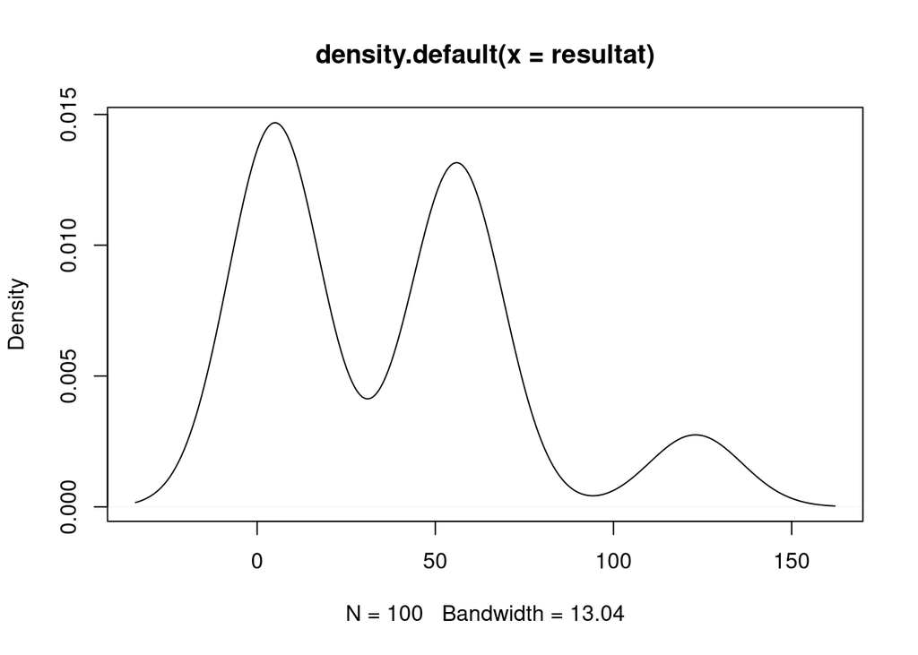

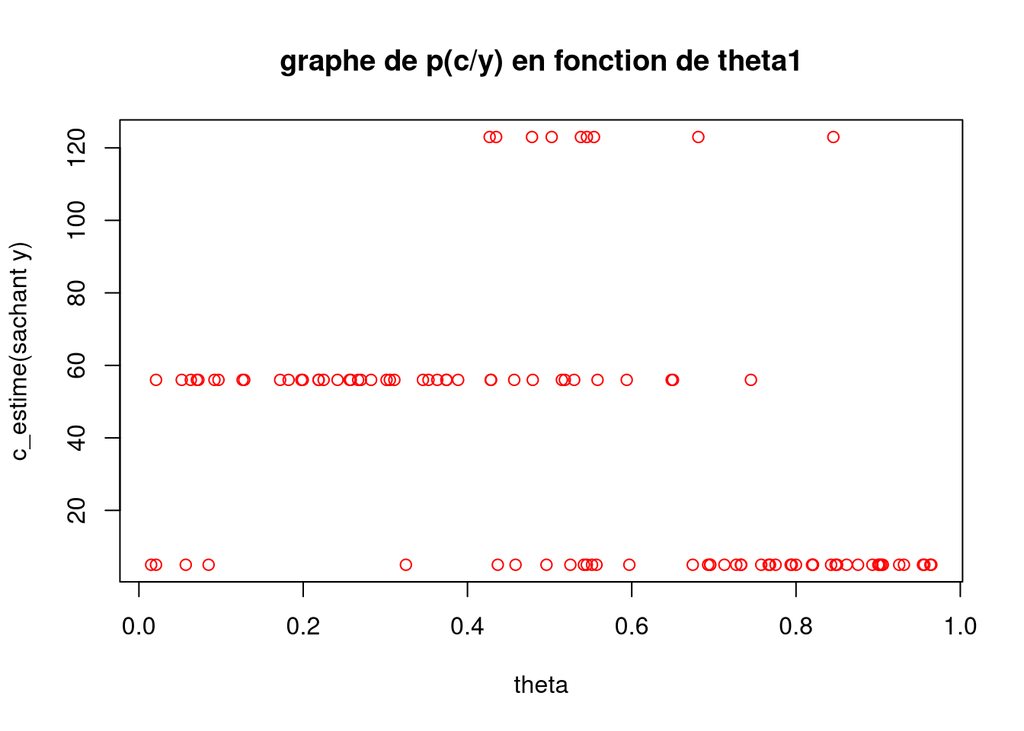

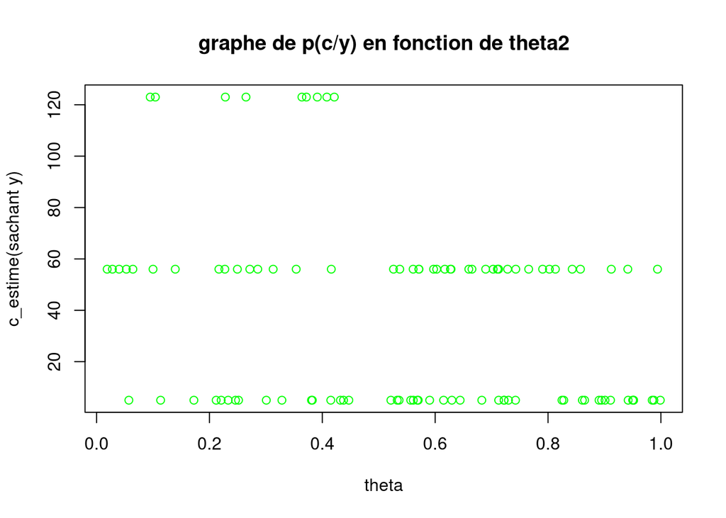

```
## [1] 0.5
## [1] 0.4761905
```

```r
vecteur3<-scan("TP2_sequence_1_2020.txt")
algo_teste_la_convergence(vecteur3)
```